# do_RSA_v8_Searchlight

LC

2024-04-30

# Load libraries and define parameters

This script is a modification to use a searchlight, instead of a parcellation/atlas.

NB: this Rmd can be used for all types of ratings: emotion, arousal, valence

Abbreviations: - sub : subjects(s) - rat : rating(s)

```r
library(tidyverse)
library(future)
library(furrr)
library(tictoc)
library(RNifti)
library(proxy) # distances
library(profvis)
library(DT)
library(formattable)

source("funs_V8.R")

bd="/data00/leonardo/RSA/analyses"

# can be emotion, arousal, valence
ratings_type <- "emotion"

# the following is our contrast of interest and it's always the same
copes_type <- "one_ev_per_movie"



# Point to which gray matter mask to use for searchlight
# GM_clean
# insula_HO_GM
gm_file <- "insula_HO"
gm_path <- paste0(bd,"/rsa/masks/", gm_file, ".nii.gz")

# Define searchlight radius in mm
r_mm <- 4


# Choose the distance metric to use for fmri RDM
# The metric for ratings RDM *should be* euclidean, since arousal and valence
# ratings have only one value
# Supported methods: 'pearson', 'spearman', 'euclidean', 'cosine' or 'mahalanobis'
dist_method_rating <- "euclidean"
dist_method_fmri = "euclidean"
dist_method_rsa = "pearson"

cat(paste0("Ratings RDM to be calculated with : ", dist_method_rating, "\n"))
```

```
## Ratings RDM to be calculated with : euclidean
```

```r
cat(paste0("fMRI RDM to be calculated with : ", dist_method_fmri, "\n"))
```

```
## fMRI RDM to be calculated with : euclidean
```

```r
# for RDM_type use:
# - tril for the lower triangular of the D matrix
# - svd for the first 3 pc from svd of the D matrix
# - in case of svd, set the number of components to return with ncomp_svd
RDM_type = "tril"  # svd or tril. Must be the same for both rating and fmri
ncomp_svd = 3

# Vector of zeropadded sub_ids
subs_file <- "/data00/leonardo/RSA/sub_list.txt"
subs <- sprintf("%02d",readLines(subs_file) %>% as.numeric)

# ---------- ONLY TOP RATERS BELOW ------------
subs <- c("02","03","12","11","22","09","29","28","26","32","23","15","20","19")
```

# Aux functions

```r
# plot_heatmap(D %>% as.matrix)
plot_heatmap <- function(M) {
  heatmap(M, Rowv = NA, Colv = NA, symm=T, revC = T)
}
```

# Create a df_path_copes with the location of the 56 cope niis from the one_movie_per_ev model

Extract the pathname of all copes using the `list.files()` function. Also define a copes_numba vector with all the copes numbers.

NB: The cope numbers in the `cope` column are NOT zeropadded since this is how they come out from FSL Feat

```r
copes_location_csv <- paste0(bd,"/rsa/copes_location.csv")

df_path_copes <- if (file.exists(copes_location_csv) ) {
  df_path_copes <- read_csv(copes_location_csv)
} else {
  df_path_copes <- import_df_path_copes(bd, copes_type)
}

copes_numba <- df_path_copes$cope %>% unique

# df_path_copes
```

# Calculate RATINGS RDMs

We do this first since the RDM for the ratings will be the same for whatever atlas will be used. Also, it’s much faster than the RDM_fmri and can be done for all the sub_ids at once.

```r
bd_ratings = paste0(bd,"/RATINGS")
ratings_path <- paste0(bd_ratings,"/",ratings_type,"_ratings.csv")
rats <- read_csv(ratings_path)

# cols are subs
# rows are elements of the tril
RDMs_rats_wider <- subs %>% map_dfc(~ {
  do_RDM_ratings_one_sub(.x, dist_method_rating, rats, RDM_type =  RDM_type)
})

# pivot the df above so that there is only one col for subs
# and one for the values of the tril for each sub
RDMs_rats <- RDMs_rats_wider %>%
  pivot_longer(cols = everything(), names_to = "sub") %>%
  arrange(sub)

RDMs_rats
```

```
## # A tibble: 21,560 × 2
##    sub   value
##    <chr> <dbl>
##  1 02     11.3
##  2 02     12.8
##  3 02     10.6
##  4 02     12.8
##  5 02     11.3
##  6 02     12.8
##  7 02     10.6
##  8 02      8
##  9 02      8
## 10 02      2
## # ℹ 21,550 more rows
```

# Calculate fMRI RDMs

## Create SEARCHLIGHT regions

```r
# 1. Read the gm mask and get voxel size, get idx of voxels in gm and their
#    xyz coordinates
gm <- readNifti(gm_path)
voxel_size <- pixdim(gm) %>% mean   # voxel size of gm
idx <- which(gm != 0)   # index of nonzero voxels
coords <- which(gm != 0, arr.ind = TRUE)   # get coordinates


# 2. Define a searchlight function returning the volume (92x109x92) idx of the
#    voxels within the searchlight
searchlight <- function(center_coord, r_mm, coords, idx, voxel_size) {

  # Calculate distance of the given voxel from every other voxel, considering voxel size
  distances <- sqrt(rowSums((t(t(coords) - center_coord) * voxel_size)^2))

  # # TEST ONLY: return the coords of the voxels in the searchlight
  # return(coords[distances <= r_mm, , drop = FALSE])

  # return the idx of the voxels in the searchlight
  return(idx[distances <= r_mm])
}


# # Testing the searchlight fn with one coordinate
# # See also the nb : earchlight_development.Rmd
# mycoord <- coords[1,]
# idx_within_radius <- searchlight(mycoord, r_mm=6, coords, idx, voxel_size)

# # Convert indices to coordinates (just to check)
# mycoord
# coords_within_radius <- coords[match(idx_within_radius, idx), , drop = FALSE]
# coords_within_radius


# 3. Get the idx of the vxls within radius for each voxel in gm (~ 20 sec)
plan(multisession, workers = 15)

tic()

idx_within_radius <- 1:length(idx) %>% future_map(
  ~ searchlight(coords[.x,], r_mm, coords, idx, voxel_size)
)

toc()
```

```
## 6.919 sec elapsed
```

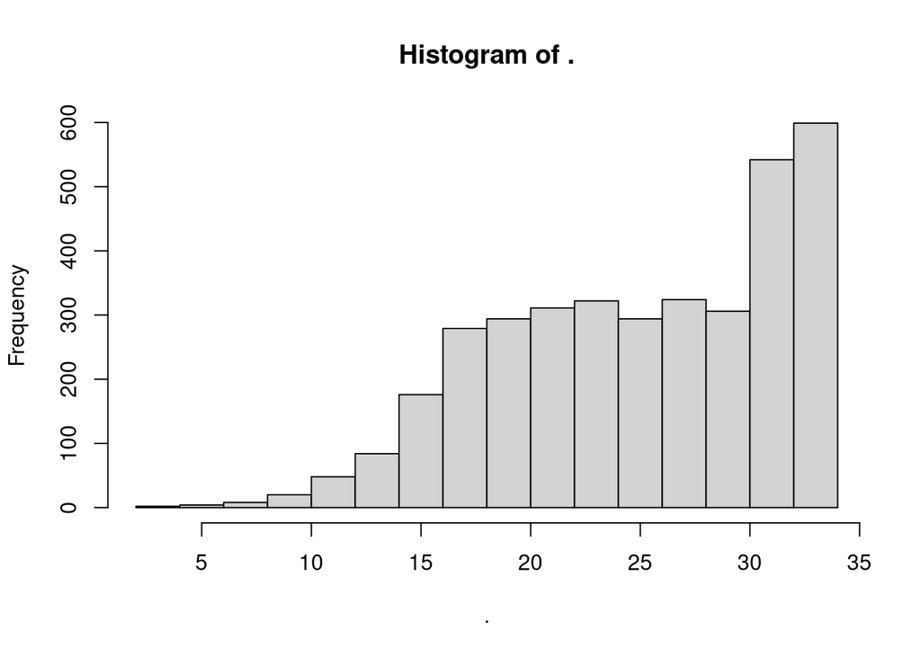

```r
plan(sequential)

idx_within_radius %>% map_dbl(length) %>% hist
```

## Fn to carry out the RMDs Searchlight calculation for one sub

```r
sub_id = "02"
df_copes <- load_sub_copes(sub_id, copes_numba, df_path_copes)


calculate_fmri_RDMs_Searchlight <- function(df_copes, idx, idx_within_radius) {

  one_rdm <- idx_within_radius %>% map_dfc(~ {
    idx_spot <- unlist(.x)
    df_copes_region <- df_copes[idx_spot, ]

    # center (i.e. demean) variables
    # (treat also the case of single voxels)
    if(nrow(df_copes_region) > 1) {
      df_copes_region_demean <- df_copes_region %>%
        mutate(across(everything(), ~ .x - mean(.x)))
    } else {
      df_copes_region_demean <- df_copes_region
    }

    # calculate distance / similarity
    D_fmri <- DDOS( t(df_copes_region_demean), method = dist_method_fmri )
    D_fmri[is.na(D_fmri)] <- 0

    # flat onto a vector
    D_feature_vector <- D_fmri[!is.na(D_fmri)]
  })

  colnames(one_rdm) = idx

  return(one_rdm)
}

# ~ 90 seconds, no need to use furrr
N <- 10 #length(idx)
one_RDM_fmri <- calculate_fmri_RDMs_Searchlight(df_copes, idx[1:N], idx_within_radius[1:N])

one_RDM_fmri
```

```
## # A tibble: 1,540 × 10
##    `263654` `263655` `263745` `263746` `273300` `273391` `273482` `273519`
##       <dbl>    <dbl>    <dbl>    <dbl>    <dbl>    <dbl>    <dbl>    <dbl>
##  1     586.    424.      641.     397.    240.      536.     834.     338.
##  2     475.    315.      510.     346.    154.      248.     400.     352.
##  3     187.     92.8     297.     208.     90.8     102.     172.     206.
##  4     282.    272.      197.     162.    248.      458.     665.     335.
##  5     412.    355.      375.     375.    436.      640.     739.     299.
##  6     291.    225.      370.     260.    323.      443.     510.     177.
##  7     233.    193.      250.     240.    184.      221.     324.     289.
##  8     227.    169.      265.     189.    123.      185.     262.     511.
##  9     198.    172.      323.     220.     93.9     203.     292.     415.
## 10     156.    127.      199.     175.    165.      222.     248.     347.
## # ℹ 1,530 more rows
## # ℹ 2 more variables: `273520` <dbl>, `273572` <dbl>
```

## Furrr the RDMs Searchlight calculation across subs

```r
# for testing on a subset of idx
N = length(idx)

# 5 workers give the best performance
plan(multisession, workers = 5)

tic()
RDMs_fmri <- subs %>% future_map_dfr(~{

  paste0("Calculating RDMs Searchlight for sub ",.x,"\n") %>% cat

  df_copes <- load_sub_copes(.x, copes_numba, df_path_copes)

  one_RDM_fmri <- calculate_fmri_RDMs_Searchlight(
    df_copes,
    idx[1:N],
    idx_within_radius[1:N]
  )

  one_RDM_fmri %>% mutate(sub = .x) %>% relocate(sub)

})
```

```
## Calculating RDMs Searchlight for sub 02
## Calculating RDMs Searchlight for sub 03
## Calculating RDMs Searchlight for sub 12
## Calculating RDMs Searchlight for sub 11
## Calculating RDMs Searchlight for sub 22
## Calculating RDMs Searchlight for sub 09
## Calculating RDMs Searchlight for sub 29
## Calculating RDMs Searchlight for sub 28
## Calculating RDMs Searchlight for sub 26
## Calculating RDMs Searchlight for sub 32
## Calculating RDMs Searchlight for sub 23
## Calculating RDMs Searchlight for sub 15
## Calculating RDMs Searchlight for sub 20
## Calculating RDMs Searchlight for sub 19
```

```r
toc()
```

```
## 244.833 sec elapsed
```

```r
plan(sequential)
```

# RSA Searchlight

```r
rdms_fmri_nested <- RDMs_fmri %>%
  pivot_longer(cols = !starts_with("sub"), names_to = "region") %>%
  group_by(sub,region) %>%
  nest() %>%
  rename(fmri = data)


rdms_rats_nested <- RDMs_rats %>%
  group_by(sub) %>%
  nest %>%
  rename(rat = data)


# we put a copy of the rating RDM for each atlas region's RDM
joint_fmri_rat_nested <- right_join(rdms_fmri_nested,rdms_rats_nested, by = "sub")
# # the following is just to check that the join went as expected
# ff %>% mutate(sum_rat = rat %>% map_dbl(sum)  )

joint_fmri_rat_nested
```

```
## # A tibble: 50,582 × 4
## # Groups:   sub, region [50,582]
##    sub   region fmri                 rat
##    <chr> <chr>  <list>               <list>
##  1 02    263654 <tibble [1,540 × 1]> <tibble [1,540 × 1]>
##  2 02    263655 <tibble [1,540 × 1]> <tibble [1,540 × 1]>
##  3 02    263745 <tibble [1,540 × 1]> <tibble [1,540 × 1]>
##  4 02    263746 <tibble [1,540 × 1]> <tibble [1,540 × 1]>
##  5 02    273300 <tibble [1,540 × 1]> <tibble [1,540 × 1]>
##  6 02    273391 <tibble [1,540 × 1]> <tibble [1,540 × 1]>
##  7 02    273482 <tibble [1,540 × 1]> <tibble [1,540 × 1]>
##  8 02    273519 <tibble [1,540 × 1]> <tibble [1,540 × 1]>
##  9 02    273520 <tibble [1,540 × 1]> <tibble [1,540 × 1]>
## 10 02    273572 <tibble [1,540 × 1]> <tibble [1,540 × 1]>
## # ℹ 50,572 more rows
```

```r
# Calculate all similarity
# This is effectively when we are calculating the RSA
all_similarities <- joint_fmri_rat_nested %>%
  mutate(
    similarity = list(fmri,rat) %>% pmap_dbl(~ cor(.x,.y, method = dist_method_rsa))
  ) %>%
  ungroup

# Produce estimates of RSA acros subjects
RSA <- all_similarities %>%
  select(region, similarity) %>%
  group_by(region) %>%
  reframe(
    mean_similarity = round(mean(similarity),2),
    sd_similarity = round(sd(similarity),2)
  ) %>%
  arrange(desc(mean_similarity))

RSA %>% datatable()
```

|  | region | mean_similarity | sd_similarity |
| --- | --- | --- | --- |
| 1 | 343916 | 0.09 | 0.12 |
| 2 | 333907 | 0.08 | 0.11 |
| 3 | 333997 | 0.08 | 0.1 |
| 4 | 333998 | 0.08 | 0.12 |
| 5 | 343825 | 0.08 | 0.11 |
| 6 | 343826 | 0.08 | 0.13 |
| 7 | 343827 | 0.08 | 0.12 |
| 8 | 343915 | 0.08 | 0.11 |
| 9 | 343917 | 0.08 | 0.13 |
| 10 | 344007 | 0.08 | 0.13 |

[output cut: 3603 more lines]

# Write the map with the values Searchlight

```r
results_to_map <- RSA %>%
  mutate(region = as.integer(region)) %>%
  select(region, mean_similarity)

results_path <- "/data00/leonardo/RSA/analyses/rsa/rsa_results"

# add the Searchlight
results_filename <- create_filename_results(
  paste0("Searchlight_",gm_file), ratings_type, dist_method_rating, dist_method_fmri, dist_method_rsa
)


# function to write the results to a nii.gz volume
write_results_to_nii <- function(results_to_map, filename_results_nii, gm) {

  results_nii = gm

  idx_to_write <- results_to_map$region
  results_nii[idx_to_write] = results_to_map$mean_similarity

  writeNifti(results_nii, filename_results_nii)
}


# Write the results nii.gz in the rsa_results dir
write_results_to_nii(
  results_to_map,
  paste0(results_path, "/", results_filename),
  gm
)
```